# Coursera’s Machine Learning Project

Oscar Benitez

Thursday, November 20, 2014

# Synopsis

Using devices such as Jawbone Up, Nike FuelBand, and Fitbit it is now possible to collect a large amount of data about personal activity relatively inexpensively. These type of devices are part of the quantified self movement - a group of enthusiasts who take measurements about themselves regularly to improve their health, to find patterns in their behavior, or because they are tech geeks. One thing that people regularly do is quantify how much of a particular activity they do, but they rarely quantify how well they do it. In this project, your goal will be to use data from accelerometers on the belt, forearm, arm, and dumbell of 6 participants. They were asked to perform barbell lifts correctly and incorrectly in 5 different ways. More information is available from the website here: http://groupware.les.inf.puc-rio.br/har (see the section on the Weight Lifting Exercise Dataset).

The goal of this project is to predict the manner of performing unilateral dumbbell biceps curls based on data from accelerometers on the belt, forearm, arm, and dumbell of 6 participants. The 5 possible methods include -

1. exactly according to the specification
2. throwing the elbows to the front
3. lifting the dumbbell only halfway
4. lowering the dumbbell only halfway
5. throwing the hips to the front

# A.Loading, exploring, cleaning and preprocessing data

The following steps were taken to adquire, explore, clean and preprocess both training and test data set

## A1.1 Set the environment and load the data

```r
library(ggplot2)
library(caret)
##setwd("C:/Users/Benitoski/Google Drive/E-learning/DataScienceSpecialization/08_PracticalMachineLearning/Project")
train0 <- read.csv("./pml-training.csv", header=TRUE, as.is = TRUE, stringsAsFactors = FALSE, sep=',', na.strings=c('NA','','#DIV/0!'))
test0<- read.csv("./pml-testing.csv", header=TRUE, as.is = TRUE, stringsAsFactors = FALSE, sep=',', na.strings=c('NA','','#DIV/0!'))
```

The size of the training set is *19622, 160* (rows by columns) and the size of the test set is *20, 160* (rows by columns)

## A1.2 Exploring the training set

The target is a factor variable with the following distribution

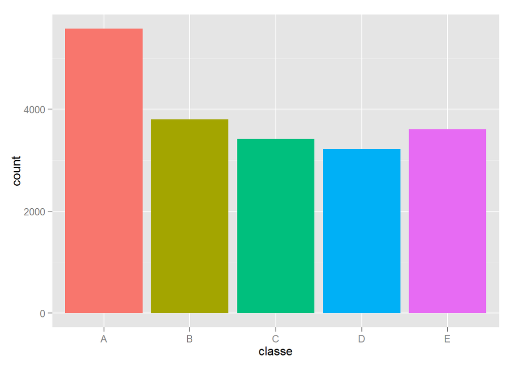

```r
ggplot(data=train0, aes(x=classe, fill=classe)) + geom_bar() + guides(fill=FALSE)
```

A quick look on the predictor variables in the data set shows that only a bunch of them has no NA values. See *Appendix - EDA training and testing data set* for more detail.

## A1.3 Cleaning the training and testing data set

The following procedure was used to clean the training set keeping only the completed variables

```r
NA_Col <- colSums(is.na(train0))
FlagCol <- NA_Col == 0
train1 <- train0[FlagCol]
```

The same set of variables was selected on the test data

```r
test1 <- test0[FlagCol]
```

## A1.4 Preprocessing the training and testing data set

In order to avoid model artifacs due to scale differences between the variables a z transformation was performed both on training and testing data set

```r
NumVars <- which(lapply(train1, class) %in% "numeric")

preObj <-preProcess(train1[,NumVars],method=c('knnImpute', 'center', 'scale'))
train2 <- predict(preObj, train1[,NumVars])
train2$classe <- train1$classe

test2 <- predict(preObj, test1[,NumVars])
```

### A1.4.1 Deleting near zero variables

The variables with near zero variation has no much prediction power, the following code identified if there are such a variables and exclude them from the analysis in case they exist

```r
nzv1 <- nearZeroVar(train2,saveMetrics=TRUE)
train3 <- train2[,nzv1$nzv==FALSE]

nzv2<-nzv1[-28,]
test3 <- test2[,nzv2$nzv==FALSE]
```

# B. Modeling

The model building stage has three steps: *sampling traning - testing data set* from the cleaning training set obtained so far, *build a model* with the new trainin data set and *test for accurracy and over - fitting* by using the new testing data set.

## B.1 New training and testing samples

The original clean training set was splitted in nwe training -testing data set (60 - 40 %, respectively) with the following code

```r
set.seed=123567
partition <- createDataPartition(y = train3$classe, p = 0.6, list = FALSE)
trainingData <- train3[partition, ]
testData <- train3[-partition, ]
```

## B.2 Model Building

The choosing model algorithm was Random Forests

“Random forests are an ensemble learning method for classification (and regression) that operate by constructing a multitude of decision trees at training time and outputting the class that is the mode of the classes output by individual trees. The algorithm for inducing a random forest was developed by Leo Breiman and Adele Cutler”… source: [Wikipedia](http://en.wikipedia.org/wiki/Random_forest)

The main features of the Random Forest algorhitm are:  
1.It is unexcelled in accuracy among current algorithms.  
2.It runs efficiently on large data bases.  
3.It can handle thousands of input variables without variable deletion.  
4.It gives estimates of what variables are important in the classification.  
5.It generates an internal unbiased estimate of the generalization error as the forest building progresses.  
6.It has an effective method for estimating missing data and maintains accuracy when a large proportion of the data are missing.  
7.It has methods for balancing error in class population unbalanced data sets. 8.Generated forests can be saved for future use on other data.  
9.Prototypes are computed that give information about the relation between the variables and the classification.  
10.It computes proximities between pairs of cases that can be used in clustering, locating outliers, or (by scaling) give interesting views of the data.  
11.The capabilities of the above can be extended to unlabeled data, leading to unsupervised clustering, data views and outlier detection.  
12.It offers an experimental method for detecting variable interactions.

source: [Berkeley University](https://www.stat.berkeley.edu/~breiman/RandomForests/cc_home.htm)

The following code was usd to buil the Random Forests model

```r
model <- train(as.factor(trainingData$classe) ~ ., data = trainingData, method = "rf", prox = TRUE,
               trControl = trainControl(method = "cv", number = 4, allowParallel = TRUE))
model
```

```
## Random Forest
##
## 11776 samples
##    27 predictor
##     5 classes: 'A', 'B', 'C', 'D', 'E'
##
## No pre-processing
## Resampling: Cross-Validated (4 fold)
##
## Summary of sample sizes: 8832, 8832, 8831, 8833
##
## Resampling results across tuning parameters:
##
##   mtry  Accuracy   Kappa      Accuracy SD  Kappa SD
##    2    0.9884510  0.9853892  0.001331064  0.001685605
##   14    0.9887061  0.9857131  0.001716322  0.002173603
##   27    0.9842899  0.9801293  0.001698387  0.002146241
##
## Accuracy was used to select the optimal model using  the largest value.
## The final value used for the model was mtry = 14.
```

## B3.Testing accurracy and over-fitting

Acurracy on the new trainig data:

```r
trainingPred <- predict(model, trainingData)
confusionMatrix(trainingPred, trainingData$classe)
```

```
## Confusion Matrix and Statistics
##
##           Reference
## Prediction    A    B    C    D    E
##          A 3348    0    0    0    0
##          B    0 2279    0    0    0
##          C    0    0 2054    0    0
##          D    0    0    0 1930    0
##          E    0    0    0    0 2165
##
## Overall Statistics
##
##                Accuracy : 1
##                  95% CI : (0.9997, 1)
##     No Information Rate : 0.2843
##     P-Value [Acc > NIR] : < 2.2e-16
##
##                   Kappa : 1
##  Mcnemar's Test P-Value : NA
##
## Statistics by Class:
##
##                      Class: A Class: B Class: C Class: D Class: E
## Sensitivity            1.0000   1.0000   1.0000   1.0000   1.0000
## Specificity            1.0000   1.0000   1.0000   1.0000   1.0000
## Pos Pred Value         1.0000   1.0000   1.0000   1.0000   1.0000
## Neg Pred Value         1.0000   1.0000   1.0000   1.0000   1.0000
## Prevalence             0.2843   0.1935   0.1744   0.1639   0.1838
## Detection Rate         0.2843   0.1935   0.1744   0.1639   0.1838
## Detection Prevalence   0.2843   0.1935   0.1744   0.1639   0.1838
## Balanced Accuracy      1.0000   1.0000   1.0000   1.0000   1.0000
```

The model performs perfectly on the new training data, but it seems that the figures are over-fitting To get an acurracy more real the model was applied to the new testing data:

```r
testingPred <- predict(model, testData)
confusionMatrix(testingPred, testData$classe)
```

```
## Confusion Matrix and Statistics
##
##           Reference
## Prediction    A    B    C    D    E
##          A 2220    8    0    0    2
##          B   11 1498    9    2    2
##          C    0   12 1343   19    3
##          D    0    0   16 1263    1
##          E    1    0    0    2 1434
##
## Overall Statistics
##
##                Accuracy : 0.9888
##                  95% CI : (0.9862, 0.991)
##     No Information Rate : 0.2845
##     P-Value [Acc > NIR] : < 2.2e-16
##
##                   Kappa : 0.9858
##  Mcnemar's Test P-Value : NA
##
## Statistics by Class:
##
##                      Class: A Class: B Class: C Class: D Class: E
## Sensitivity            0.9946   0.9868   0.9817   0.9821   0.9945
## Specificity            0.9982   0.9962   0.9948   0.9974   0.9995
## Pos Pred Value         0.9955   0.9842   0.9753   0.9867   0.9979
## Neg Pred Value         0.9979   0.9968   0.9961   0.9965   0.9988
## Prevalence             0.2845   0.1935   0.1744   0.1639   0.1838
## Detection Rate         0.2829   0.1909   0.1712   0.1610   0.1828
## Detection Prevalence   0.2842   0.1940   0.1755   0.1631   0.1832
## Balanced Accuracy      0.9964   0.9915   0.9882   0.9898   0.9970
```

# C. Predictions

Applying the model on the real testing set the results are:

```r
answer <- predict(model, test3)
answer <- as.character(answer)
answer
```

```
##  [1] "B" "A" "B" "A" "A" "E" "D" "B" "A" "A" "B" "C" "B" "A" "E" "E" "A"
## [18] "B" "B" "B"
```

Those results were written to 20 separate files, as instructed wth the following code:

pml_write_files = function(x){  
n = length(x)  
for(i in 1:n){  
filename = paste0(“problem_id_”,i,“.txt”)  
write.table(x[i],file=filename,quote=FALSE,row.names=FALSE,col.names=FALSE)  
}  
}

pml_write_files(answer)

After submit all the answers the score obtained was 20/20

# Conclusion

The combination of selecting completed variables, applying z transformation on the predictors and random forest modeling, produced a high acurracy, low over-fitted model for this particular data set.

## Apendix

### EDA Training data set

```r
summary(train0)
```

```
##        X          user_name         raw_timestamp_part_1
##  Min.   :    1   Length:19622       Min.   :1.322e+09
##  1st Qu.: 4906   Class :character   1st Qu.:1.323e+09
##  Median : 9812   Mode  :character   Median :1.323e+09
##  Mean   : 9812                      Mean   :1.323e+09
##  3rd Qu.:14717                      3rd Qu.:1.323e+09
##  Max.   :19622                      Max.   :1.323e+09
##
##  raw_timestamp_part_2 cvtd_timestamp      new_window
##  Min.   :   294       Length:19622       Length:19622
##  1st Qu.:252912       Class :character   Class :character
##  Median :496380       Mode  :character   Mode  :character
##  Mean   :500656
##  3rd Qu.:751891
##  Max.   :998801
##
##    num_window      roll_belt        pitch_belt          yaw_belt
##  Min.   :  1.0   Min.   :-28.90   Min.   :-55.8000   Min.   :-180.00
##  1st Qu.:222.0   1st Qu.:  1.10   1st Qu.:  1.7600   1st Qu.: -88.30
##  Median :424.0   Median :113.00   Median :  5.2800   Median : -13.00
##  Mean   :430.6   Mean   : 64.41   Mean   :  0.3053   Mean   : -11.21
##  3rd Qu.:644.0   3rd Qu.:123.00   3rd Qu.: 14.9000   3rd Qu.:  12.90
##  Max.   :864.0   Max.   :162.00   Max.   : 60.3000   Max.   : 179.00
##
##  total_accel_belt kurtosis_roll_belt kurtosis_picth_belt kurtosis_yaw_belt
##  Min.   : 0.00    Min.   :-2.121     Min.   :-2.190      Mode:logical
##  1st Qu.: 3.00    1st Qu.:-1.329     1st Qu.:-1.107      NA's:19622
##  Median :17.00    Median :-0.899     Median :-0.151
##  Mean   :11.31    Mean   :-0.220     Mean   : 4.334
##  3rd Qu.:18.00    3rd Qu.:-0.219     3rd Qu.: 3.178
##  Max.   :29.00    Max.   :33.000     Max.   :58.000
##                   NA's   :19226      NA's   :19248
##  skewness_roll_belt skewness_roll_belt.1 skewness_yaw_belt
##  Min.   :-5.745     Min.   :-7.616       Mode:logical
##  1st Qu.:-0.444     1st Qu.:-1.114       NA's:19622
##  Median : 0.000     Median :-0.068
##  Mean   :-0.026     Mean   :-0.296
##  3rd Qu.: 0.417     3rd Qu.: 0.661
##  Max.   : 3.595     Max.   : 7.348
##  NA's   :19225      NA's   :19248
```

[output cut: 313 more lines]

```
##  Min.   : -8.0900   Min.   :-498.00   Min.   :-632.0   Min.   :-446.00
##  1st Qu.: -0.1800   1st Qu.:-178.00   1st Qu.:  57.0   1st Qu.:-182.00
##  Median :  0.0800   Median : -57.00   Median : 201.0   Median : -39.00
##  Mean   :  0.1512   Mean   : -61.65   Mean   : 163.7   Mean   : -55.29
##  3rd Qu.:  0.4900   3rd Qu.:  76.00   3rd Qu.: 312.0   3rd Qu.:  26.00
##  Max.   :231.0000   Max.   : 477.00   Max.   : 923.0   Max.   : 291.00
##
##  magnet_forearm_x  magnet_forearm_y magnet_forearm_z    classe
##  Min.   :-1280.0   Min.   :-896.0   Min.   :-973.0   Length:19622
##  1st Qu.: -616.0   1st Qu.:   2.0   1st Qu.: 191.0   Class :character
##  Median : -378.0   Median : 591.0   Median : 511.0   Mode  :character
##  Mean   : -312.6   Mean   : 380.1   Mean   : 393.6
##  3rd Qu.:  -73.0   3rd Qu.: 737.0   3rd Qu.: 653.0
##  Max.   :  672.0   Max.   :1480.0   Max.   :1090.0
##
```

### EDA Testing data set

```r
summary(test0)
```

```
##        X          user_name         raw_timestamp_part_1
##  Min.   : 1.00   Length:20          Min.   :1.322e+09
##  1st Qu.: 5.75   Class :character   1st Qu.:1.323e+09
##  Median :10.50   Mode  :character   Median :1.323e+09
##  Mean   :10.50                      Mean   :1.323e+09
##  3rd Qu.:15.25                      3rd Qu.:1.323e+09
##  Max.   :20.00                      Max.   :1.323e+09
##  raw_timestamp_part_2 cvtd_timestamp      new_window
##  Min.   : 36553       Length:20          Length:20
##  1st Qu.:268655       Class :character   Class :character
##  Median :530706       Mode  :character   Mode  :character
##  Mean   :512167
##  3rd Qu.:787738
##  Max.   :920315
##    num_window      roll_belt          pitch_belt         yaw_belt
##  Min.   : 48.0   Min.   : -5.9200   Min.   :-41.600   Min.   :-93.70
##  1st Qu.:250.0   1st Qu.:  0.9075   1st Qu.:  3.013   1st Qu.:-88.62
##  Median :384.5   Median :  1.1100   Median :  4.655   Median :-87.85
##  Mean   :379.6   Mean   : 31.3055   Mean   :  5.824   Mean   :-59.30
##  3rd Qu.:467.0   3rd Qu.: 32.5050   3rd Qu.:  6.135   3rd Qu.:-63.50
##  Max.   :859.0   Max.   :129.0000   Max.   : 27.800   Max.   :162.00
##  total_accel_belt kurtosis_roll_belt kurtosis_picth_belt kurtosis_yaw_belt
##  Min.   : 2.00    Mode:logical       Mode:logical        Mode:logical
##  1st Qu.: 3.00    NA's:20            NA's:20             NA's:20
##  Median : 4.00
##  Mean   : 7.55
##  3rd Qu.: 8.00
##  Max.   :21.00
##  skewness_roll_belt skewness_roll_belt.1 skewness_yaw_belt max_roll_belt
##  Mode:logical       Mode:logical         Mode:logical      Mode:logical
##  NA's:20            NA's:20              NA's:20           NA's:20
##
##
##
##
##  max_picth_belt max_yaw_belt   min_roll_belt  min_pitch_belt
##  Mode:logical   Mode:logical   Mode:logical   Mode:logical
##  NA's:20        NA's:20        NA's:20        NA's:20
##
##
```

[output cut: 253 more lines]

```
##                  Max.   : 1.3800   Max.   : 4.2600   Max.   : 1.8000
##  accel_forearm_x  accel_forearm_y  accel_forearm_z  magnet_forearm_x
##  Min.   :-212.0   Min.   :-331.0   Min.   :-282.0   Min.   :-714.0
##  1st Qu.:-114.8   1st Qu.:   8.5   1st Qu.:-199.0   1st Qu.:-427.2
##  Median :  86.0   Median : 138.0   Median :-148.5   Median :-189.5
##  Mean   :  38.8   Mean   : 125.3   Mean   : -93.7   Mean   :-159.2
##  3rd Qu.: 166.2   3rd Qu.: 268.0   3rd Qu.: -31.0   3rd Qu.:  41.5
##  Max.   : 232.0   Max.   : 406.0   Max.   : 179.0   Max.   : 532.0
##  magnet_forearm_y magnet_forearm_z   problem_id
##  Min.   :-787.0   Min.   :-32.0    Min.   : 1.00
##  1st Qu.:-328.8   1st Qu.:275.2    1st Qu.: 5.75
##  Median : 487.0   Median :491.5    Median :10.50
##  Mean   : 191.8   Mean   :460.2    Mean   :10.50
##  3rd Qu.: 720.8   3rd Qu.:661.5    3rd Qu.:15.25
##  Max.   : 800.0   Max.   :884.0    Max.   :20.00
```